# Statistical Technique Assignment

Kartheek Raj

1/7/2020

## Abstract

This report contains the methods used to extract insights from Fuel Consumption data set. Multiple analytical tests are performed in order to find any relations between features and investigate the car models and features causing the CO2 emission.Statistical tests like – Pearson Correlation,ANOVA, Wilcoxon signed rank test, Bartlett Test, etc. are performed on the mentioned set of data.

## Introduction

Automobiles are ubiquitous in our daily lives as means of transportation from point A to point B. Cars we know today has wide variety options and has come so far from early bare bone versions. Ford motor made the milestone by their 1908 model from the inception to reality cars accessible to the masses. Cars presence exploded every aspect in this century from pizza delivery to personal transportation. Automobiles not only comes with fiction but also with pollution like CO2 emission, infrastructure like roads and Natural resources like metals (CNBC, 2020). After 2008 financial crisis, as economy recovered consumers preferred less mileage and larger car segment i.e. sports utility vehicle (SUV). In other words, SUV CO2 emissions are higher than less mileage cars (Stevens, 2020). SUV carbon foot print is 544 metric tons from 2010 to 2018 which is directly contributing to global warming. In this report we investigate features impacting CO2 emissions using Fuel Consumption Data set.

## Description of Fuel Consumption Data set.

### Features Description as follows:

**Year**: This feature is about the year the data collected i.e. 2014.

**Make**: This feature is about the name of the car manufacturers and contains 39 makers.

**Model**: This feature is about the name of the car model and contains 663 models.

**Vehicle Class**: This feature is about the name of the car vehicle type and contains 16 types.

**Engine Size**: This feature is about the size of the engine in litters and contains 45 engine sizes.

**Cylinders**: This feature is about the no of cylinders in the engine and contains 7 unique cylinder setups.

**Transmission**: This feature is about the name of the car transmission type and contains 22 different types.

**Fuel Type**: This feature is about the fuel types consumed by all cars and contains 4 fuel types.

**Fuel Consumption city**: This feature is about the mileage of the car in city conditions and range from 4.6 to 30.2.

**Fuel Consumption Highway**: This feature is about the mileage of the car in highway conditions and the range from 4.9 to 20.5.

**Fuel Consumption Combined**: This feature is about the mileage of the both previous conditions combined and the range from 4.7 to 25.8.

**Fuel Consumption mile per gallon**: This feature is about the car can travel no of miles per gallon and the range from 11 to 60.

## Project Aims and Objective

This project will be carried out by answering following questions. We will apply statistical techniques in order to get the insights from automobile data set collected from 2014.

### Objective:

What are the most contributing factors that leads to CO2 emission?

How the fuel mileage varies across SUV Vehicle class models?

Car Makers and their impact in the year 2014.

ANOVA, Bartlett Test and Non parametric test method to check if the differences between the groups are statistically significant.

Pearson’s R correlation can be used to see the strength of association between quantitative variables.

### Code and its explanation

**Setting working directory.**

```r
require(ggplot2)
require(GGally)
require(corrplot)
library(ggplot2)
library(GGally)

getwd()
```

```
## [1] "C:/Users/mkart/OneDrive/Documents/Projects/Stats"
```

```r
Fuel_Consumption<-read.csv("FuelConsumption.csv")
Fuel_Consumption<-data.frame(Fuel_Consumption)
```

We imported the data from local machine to r platform and renamed the data set to Fuel_Consumption.Next, we look for these observations:

```r
dim(Fuel_Consumption)
```

```
## [1] 1067   13
```

```r
str(Fuel_Consumption)
```

```
## 'data.frame':    1067 obs. of  13 variables:
##  $ MODELYEAR               : int  2014 2014 2014 2014 2014 2014 2014 2014 2014 2014 ...
##  $ MAKE                    : Factor w/ 39 levels "ACURA","ASTON MARTIN",..: 1 1 1 1 1 1 1 1 1 1 ...
##  $ MODEL                   : Factor w/ 663 levels "1500 (MDS)","1500 4X4 (MDS)",..: 330 330 331 391 485 492 581 582 582 594 ...
##  $ VEHICLECLASS            : Factor w/ 16 levels "COMPACT","FULL-SIZE",..: 1 1 1 12 12 3 3 3 3 1 ...
##  $ ENGINESIZE              : num  2 2.4 1.5 3.5 3.5 3.5 3.5 3.7 3.7 2.4 ...
##  $ CYLINDERS               : int  4 4 4 6 6 6 6 6 6 4 ...
##  $ TRANSMISSION            : Factor w/ 22 levels "A4","A5","A6",..: 11 21 18 12 12 12 12 12 21 11 ...
##  $ FUELTYPE                : Factor w/ 4 levels "D","E","X","Z": 4 4 4 4 4 4 4 4 4 4 ...
##  $ FUELCONSUMPTION_CITY    : num  9.9 11.2 6 12.7 12.1 11.9 11.8 12.8 13.4 10.6 ...
##  $ FUELCONSUMPTION_HWY     : num  6.7 7.7 5.8 9.1 8.7 7.7 8.1 9 9.5 7.5 ...
##  $ FUELCONSUMPTION_COMB    : num  8.5 9.6 5.9 11.1 10.6 10 10.1 11.1 11.6 9.2 ...
##  $ FUELCONSUMPTION_COMB_MPG: int  33 29 48 25 27 28 28 25 24 31 ...
##  $ CO2EMISSIONS            : int  196 221 136 255 244 230 232 255 267 212 ...
```

```r
head(Fuel_Consumption)
```

|  | MODELYEAR | MAKE | MODEL | VEHICLECLASS | ENGINESIZE | CYLINDERS | TRANSMISSION | FUELTYPE | FUELCONSUMPTION_CITY | FUELCONSUMPTION_HWY | FUELCONSUMPTION_COMB | FUELCONSUMPTION_COMB_MPG | CO2EMISSIONS |
| --- | --- | --- | --- | --- | --- | --- | --- | --- | --- | --- | --- | --- | --- |
| 1 | 2014 | ACURA | ILX | COMPACT | 2.0 | 4 | AS5 | Z | 9.9 | 6.7 | 8.5 | 33 | 196 |
| 2 | 2014 | ACURA | ILX | COMPACT | 2.4 | 4 | M6 | Z | 11.2 | 7.7 | 9.6 | 29 | 221 |
| 3 | 2014 | ACURA | ILX HYBRID | COMPACT | 1.5 | 4 | AV7 | Z | 6.0 | 5.8 | 5.9 | 48 | 136 |
| 4 | 2014 | ACURA | MDX 4WD | SUV - SMALL | 3.5 | 6 | AS6 | Z | 12.7 | 9.1 | 11.1 | 25 | 255 |
| 5 | 2014 | ACURA | RDX AWD | SUV - SMALL | 3.5 | 6 | AS6 | Z | 12.1 | 8.7 | 10.6 | 27 | 244 |
| 6 | 2014 | ACURA | RLX | MID-SIZE | 3.5 | 6 | AS6 | Z | 11.9 | 7.7 | 10.0 | 28 | 230 |

```r
summary(Fuel_Consumption)
```

```
##    MODELYEAR               MAKE              MODEL              VEHICLECLASS
##  Min.   :2014   FORD         : 90   F150 FFV    :   8   MID-SIZE      :178
##  1st Qu.:2014   CHEVROLET    : 86   F150 FFV 4X4:   8   COMPACT       :172
##  Median :2014   BMW          : 64   ACCORD      :   6   SUV - SMALL   :154
##  Mean   :2014   MERCEDES-BENZ: 59   BEETLE      :   6   SUV - STANDARD:110
##  3rd Qu.:2014   AUDI         : 49   FOCUS FFV   :   6   FULL-SIZE     : 86
##  Max.   :2014   GMC          : 49   MUSTANG     :   5   TWO-SEATER    : 71
##                 (Other)      :670   (Other)     :1028   (Other)       :296
##    ENGINESIZE      CYLINDERS       TRANSMISSION FUELTYPE FUELCONSUMPTION_CITY
##  Min.   :1.000   Min.   : 3.000   A6     :222   D: 27    Min.   : 4.60
##  1st Qu.:2.000   1st Qu.: 4.000   AS6    :189   E: 92    1st Qu.:10.25
##  Median :3.400   Median : 6.000   M6     :141   X:514    Median :12.60
##  Mean   :3.346   Mean   : 5.795   A8     : 87   Z:434    Mean   :13.30
##  3rd Qu.:4.300   3rd Qu.: 8.000   AS8    : 80            3rd Qu.:15.55
##  Max.   :8.400   Max.   :12.000   AS7    : 76            Max.   :30.20
##                                   (Other):272
##  FUELCONSUMPTION_HWY FUELCONSUMPTION_COMB FUELCONSUMPTION_COMB_MPG
##  Min.   : 4.900      Min.   : 4.70        Min.   :11.00
##  1st Qu.: 7.500      1st Qu.: 9.00        1st Qu.:21.00
##  Median : 8.800      Median :10.90        Median :26.00
##  Mean   : 9.475      Mean   :11.58        Mean   :26.44
##  3rd Qu.:10.850      3rd Qu.:13.35        3rd Qu.:31.00
##  Max.   :20.500      Max.   :25.80        Max.   :60.00
##
##   CO2EMISSIONS
##  Min.   :108.0
##  1st Qu.:207.0
##  Median :251.0
##  Mean   :256.2
##  3rd Qu.:294.0
##  Max.   :488.0
##
```

## Exploratory data analysis

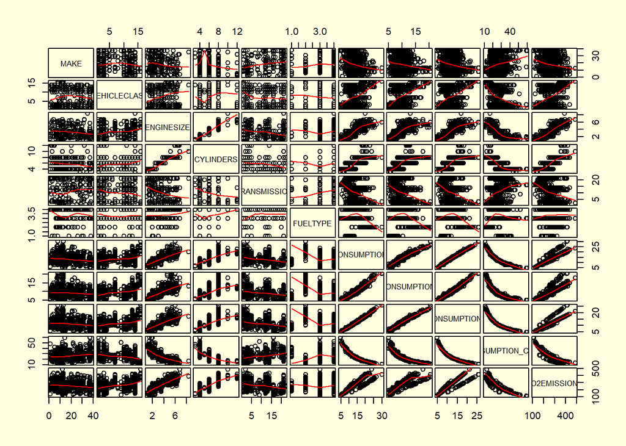

```r
par(mfrow=c(1,1),bg="lightyellow")
pairs(Fuel_Consumption[,c(-3,-1)],panel = panel.smooth,gap=1/4)
```

### Box plots

```r
par(mfrow=c(1,1),bg="lightyellow")

sum(is.na(Fuel_Consumption))
```

```
## [1] 0
```

```r
sum(is.null(Fuel_Consumption))
```

```
## [1] 0
```

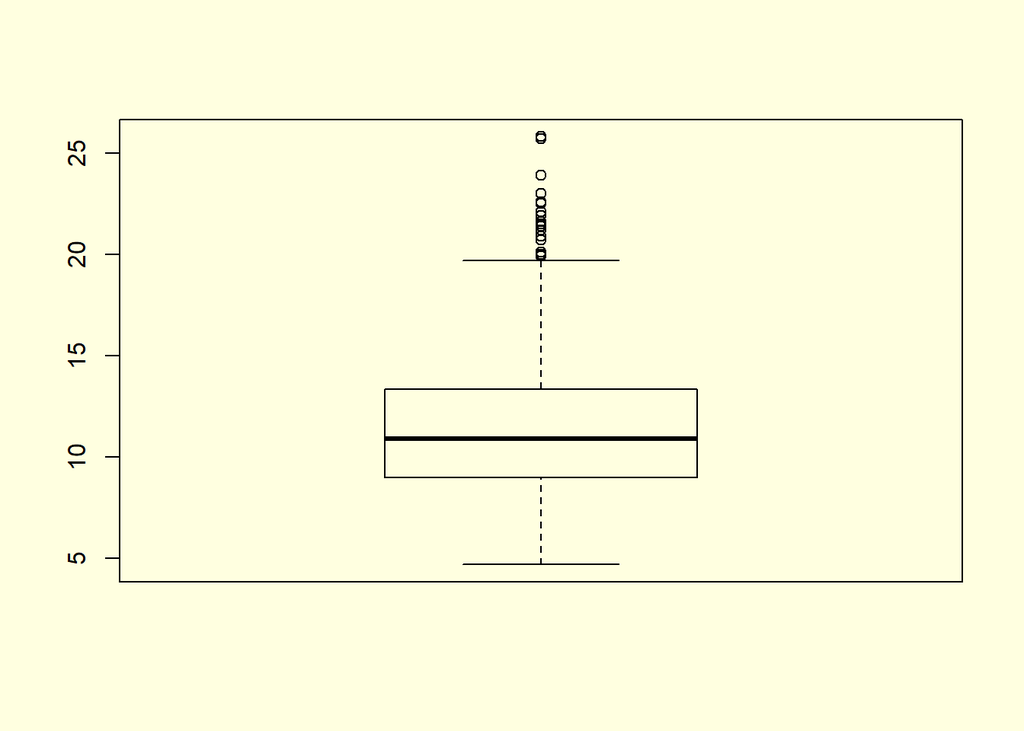

```r
boxplot(Fuel_Consumption$FUELCONSUMPTION_COMB)
```

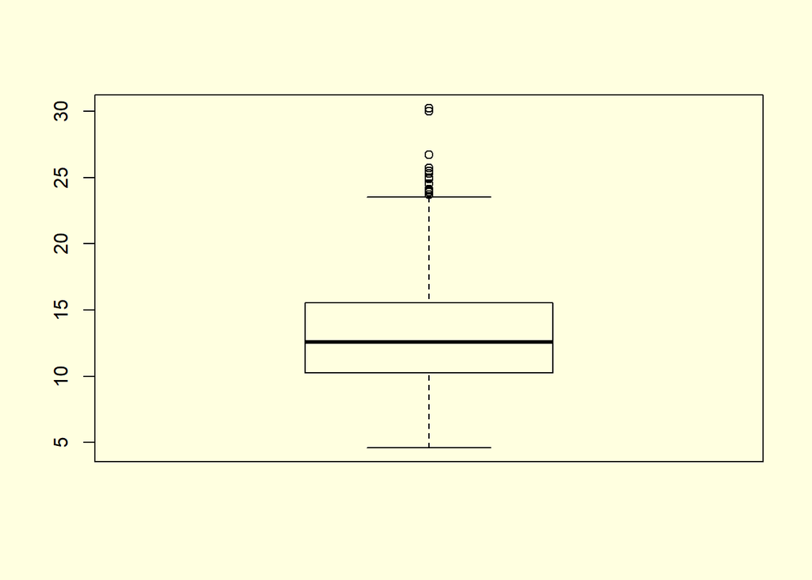

```r
boxplot(Fuel_Consumption$FUELCONSUMPTION_CITY)
```

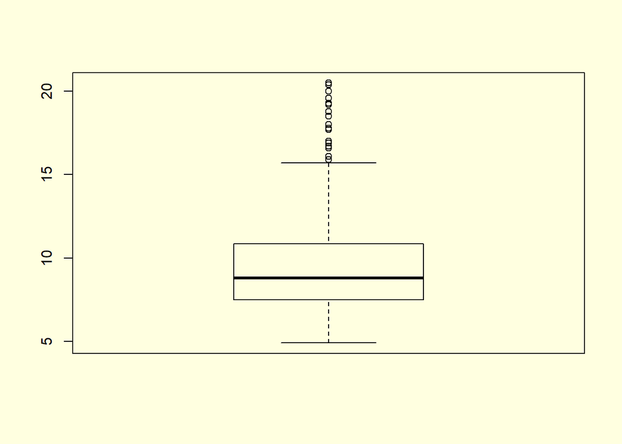

```r
boxplot(Fuel_Consumption$FUELCONSUMPTION_HWY)
```

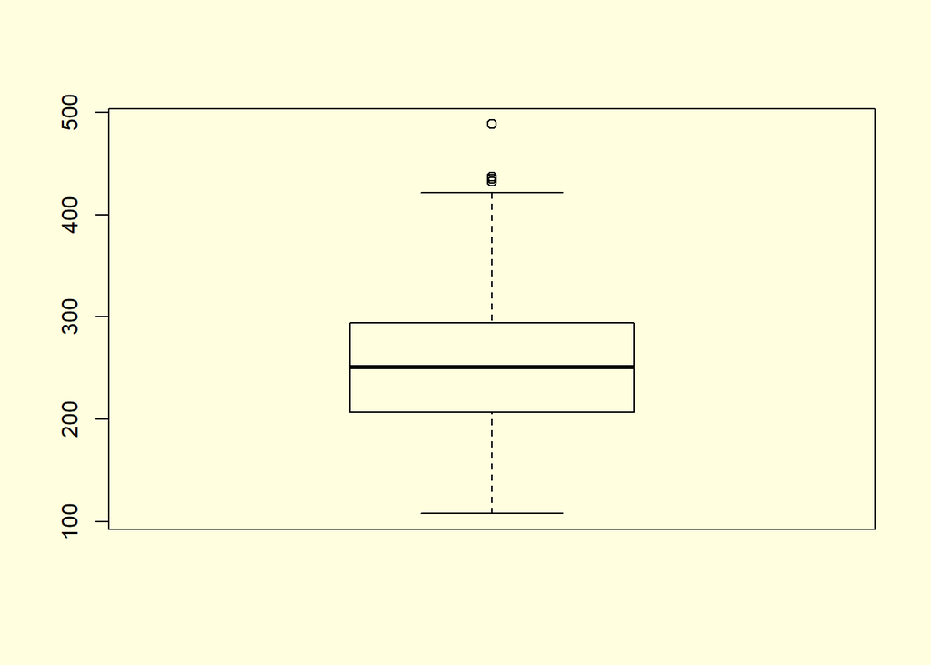

```r
boxplot(Fuel_Consumption$CO2EMISSIONS)
```

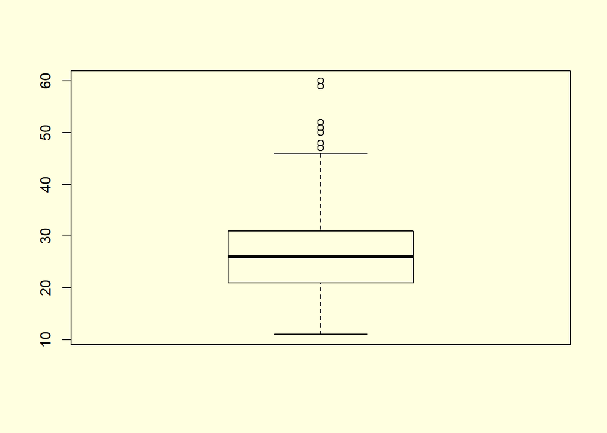

```r
boxplot(Fuel_Consumption$FUELCONSUMPTION_COMB_MPG)
```

### Histograms

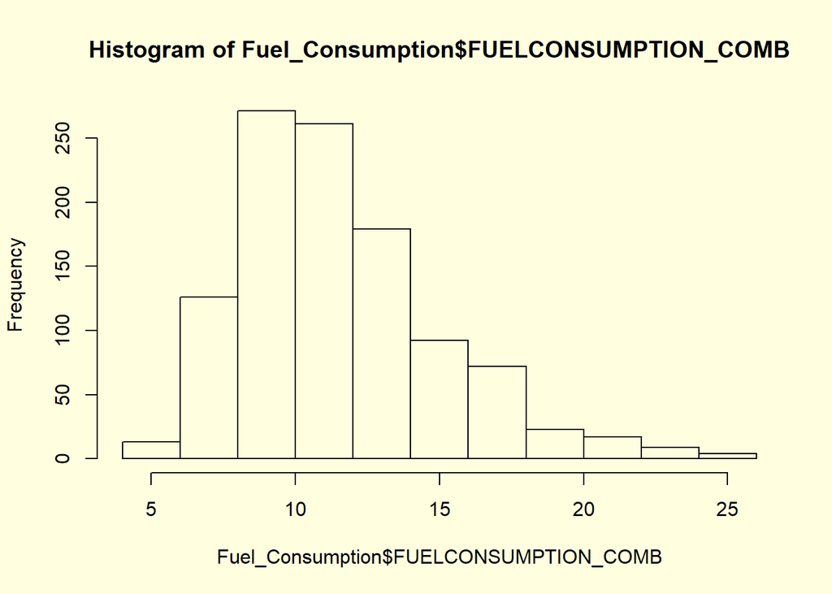

```r
par(mfrow=c(1,1),bg="lightyellow")
hist(Fuel_Consumption$FUELCONSUMPTION_COMB)
```

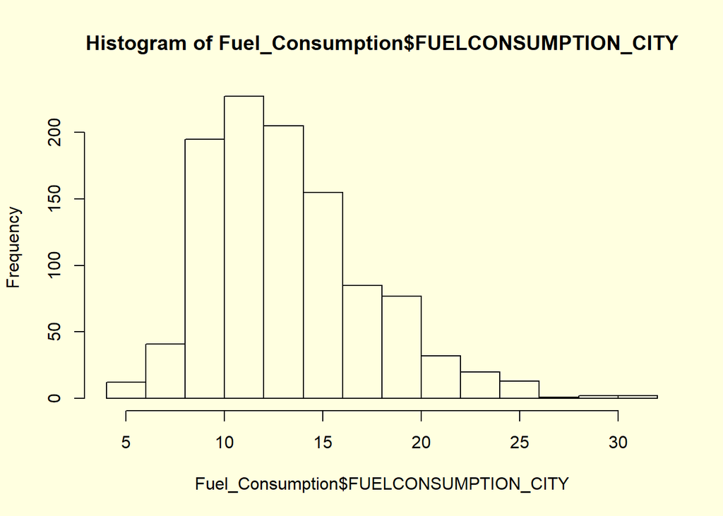

```r
hist(Fuel_Consumption$FUELCONSUMPTION_CITY)
```

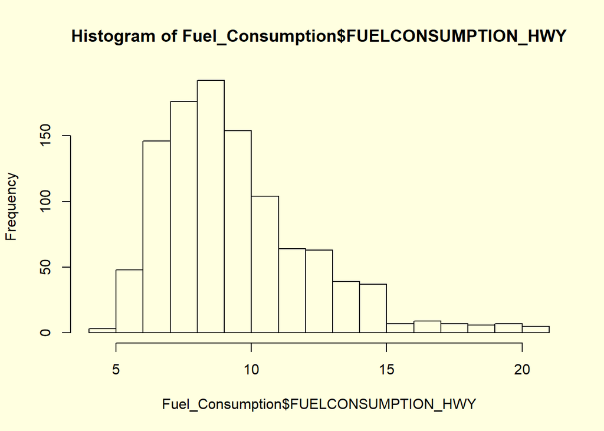

```r
hist(Fuel_Consumption$FUELCONSUMPTION_HWY)
```

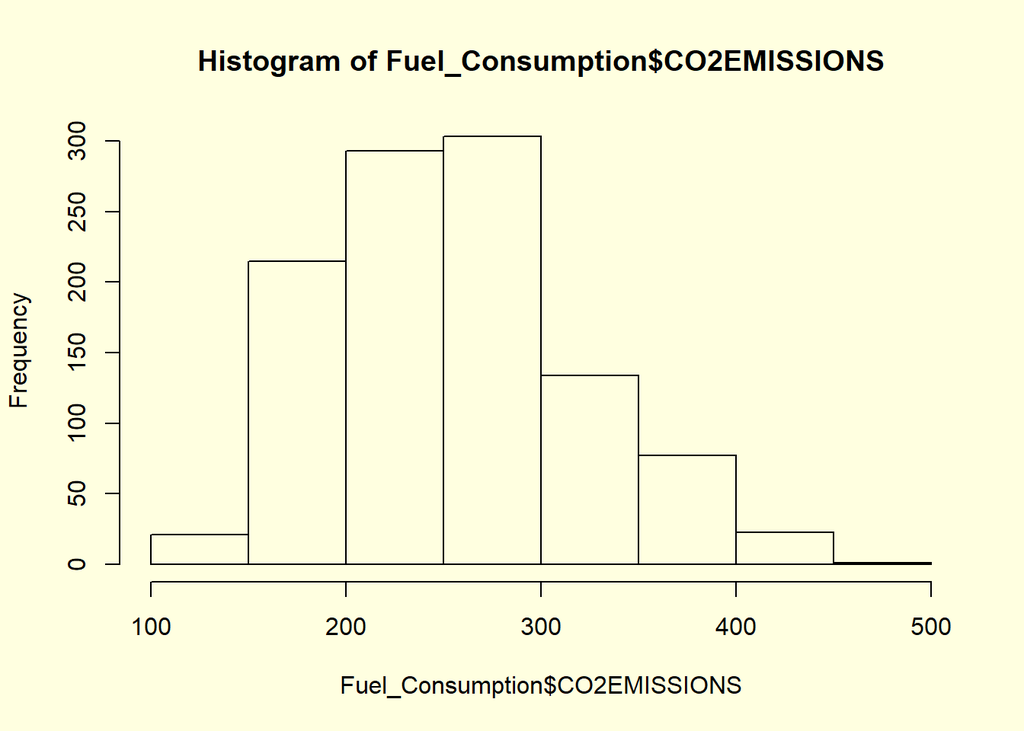

```r
hist(Fuel_Consumption$CO2EMISSIONS)
```

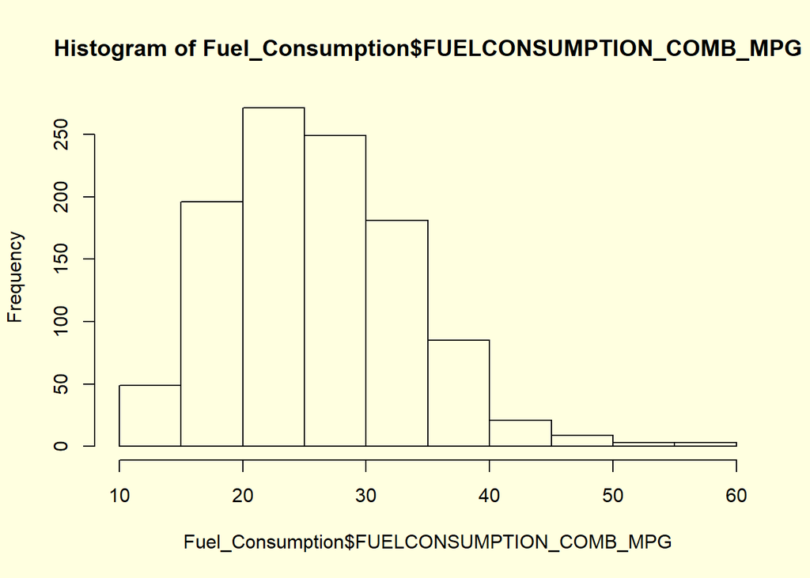

```r
hist(Fuel_Consumption$FUELCONSUMPTION_COMB_MPG)
```

**Altering the data types for our problem.**

```r
Fuel_Consumption$CYLINDERS<-as.factor(Fuel_Consumption$CYLINDERS)
Fuel_Consumption$ENGINESIZE<-as.factor(Fuel_Consumption$ENGINESIZE)
Fuel_Consumption$MODELYEAR<-as.factor(Fuel_Consumption$MODELYEAR)

str(Fuel_Consumption)
```

```
## 'data.frame':    1067 obs. of  13 variables:
##  $ MODELYEAR               : Factor w/ 1 level "2014": 1 1 1 1 1 1 1 1 1 1 ...
##  $ MAKE                    : Factor w/ 39 levels "ACURA","ASTON MARTIN",..: 1 1 1 1 1 1 1 1 1 1 ...
##  $ MODEL                   : Factor w/ 663 levels "1500 (MDS)","1500 4X4 (MDS)",..: 330 330 331 391 485 492 581 582 582 594 ...
##  $ VEHICLECLASS            : Factor w/ 16 levels "COMPACT","FULL-SIZE",..: 1 1 1 12 12 3 3 3 3 1 ...
##  $ ENGINESIZE              : Factor w/ 45 levels "1","1.2","1.3",..: 8 10 5 17 17 17 17 19 19 10 ...
##  $ CYLINDERS               : Factor w/ 7 levels "3","4","5","6",..: 2 2 2 4 4 4 4 4 4 2 ...
##  $ TRANSMISSION            : Factor w/ 22 levels "A4","A5","A6",..: 11 21 18 12 12 12 12 12 21 11 ...
##  $ FUELTYPE                : Factor w/ 4 levels "D","E","X","Z": 4 4 4 4 4 4 4 4 4 4 ...
##  $ FUELCONSUMPTION_CITY    : num  9.9 11.2 6 12.7 12.1 11.9 11.8 12.8 13.4 10.6 ...
##  $ FUELCONSUMPTION_HWY     : num  6.7 7.7 5.8 9.1 8.7 7.7 8.1 9 9.5 7.5 ...
##  $ FUELCONSUMPTION_COMB    : num  8.5 9.6 5.9 11.1 10.6 10 10.1 11.1 11.6 9.2 ...
##  $ FUELCONSUMPTION_COMB_MPG: int  33 29 48 25 27 28 28 25 24 31 ...
##  $ CO2EMISSIONS            : int  196 221 136 255 244 230 232 255 267 212 ...
```

**Data splits includes train/test and numeric and non numeric features.**

```r
set.seed(1234)

ids = sample(nrow(Fuel_Consumption), nrow(Fuel_Consumption)*0.6)
train<-data.frame(Fuel_Consumption[ids,])
test<-data.frame(Fuel_Consumption[-ids,])

num_data<-Fuel_Consumption[,c(9:13)]
factorial_data<-Fuel_Consumption[,-c(9:13)]
```

### Correlation

we apply Pearson correlation, assuming that features are normally distributed for linearity established between the numerical features. Correlation coefficient above 0 is positive and below 0 is negative. If the correlation coefficients are 1, -1,then they are perfectly correlated with each other and zero means no correlation is established. Correlation coefficient is mathematically defined as (James et al., n.d.).

$$r = \frac{{}\sum_{i=1}^{n} (x_i - \overline{x})(y_i - \overline{y})}
{\sqrt{\sum_{i=1}^{n} (x_i - \overline{x})^2(y_i - \overline{y})^2}}$$

**Correlation test on numerical Features found fuel consumption is negatively correlated to highway, city and combined mileage. highway, city and combined reflects positive correlation.Building the Linear model we will consider only combined mileage for the same reason**

```r
library(corrplot)

Fuel_Consumption_cor<-cor(num_data)
Fuel_Consumption_cor
```

```
##                          FUELCONSUMPTION_CITY FUELCONSUMPTION_HWY
## FUELCONSUMPTION_CITY                1.0000000           0.9657182
## FUELCONSUMPTION_HWY                 0.9657182           1.0000000
## FUELCONSUMPTION_COMB                0.9955424           0.9858038
## FUELCONSUMPTION_COMB_MPG           -0.9356126          -0.8938086
## CO2EMISSIONS                        0.8980385           0.8617479
##                          FUELCONSUMPTION_COMB FUELCONSUMPTION_COMB_MPG
## FUELCONSUMPTION_CITY                0.9955424               -0.9356126
## FUELCONSUMPTION_HWY                 0.9858038               -0.8938086
## FUELCONSUMPTION_COMB                1.0000000               -0.9279651
## FUELCONSUMPTION_COMB_MPG           -0.9279651                1.0000000
## CO2EMISSIONS                        0.8921286               -0.9063942
##                          CO2EMISSIONS
## FUELCONSUMPTION_CITY        0.8980385
## FUELCONSUMPTION_HWY         0.8617479
## FUELCONSUMPTION_COMB        0.8921286
## FUELCONSUMPTION_COMB_MPG   -0.9063942
## CO2EMISSIONS                1.0000000
```

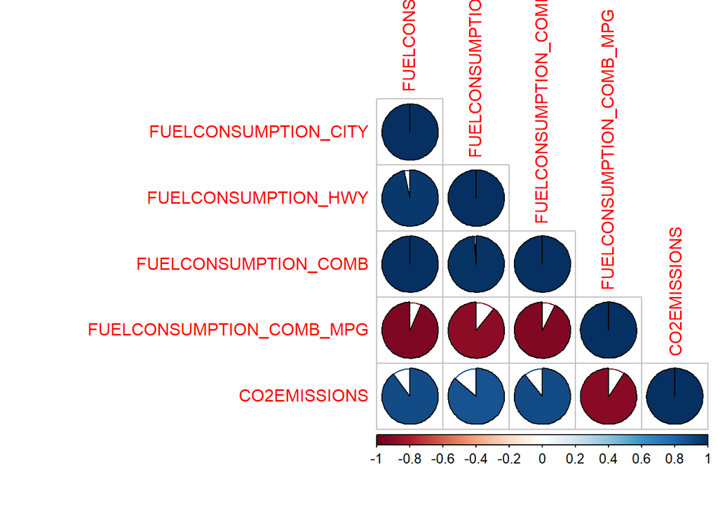

```r
corrplot(Fuel_Consumption_cor,method = "pie",type="lower")
```

### Bar chart

Bar chart is a visualization of categorical data against aggregate function. Each bar shows the aggregate of that category (Docs.tibco.com, 2020).

**Bar plots on Fuel consumption data set convey the following results. First inference is Ford produces more cars than other manufacturer. Secondly, mid size models are positioned as largest vehicle type and last inference is 2liter engine and fuel type x follows the same highest distribution.**

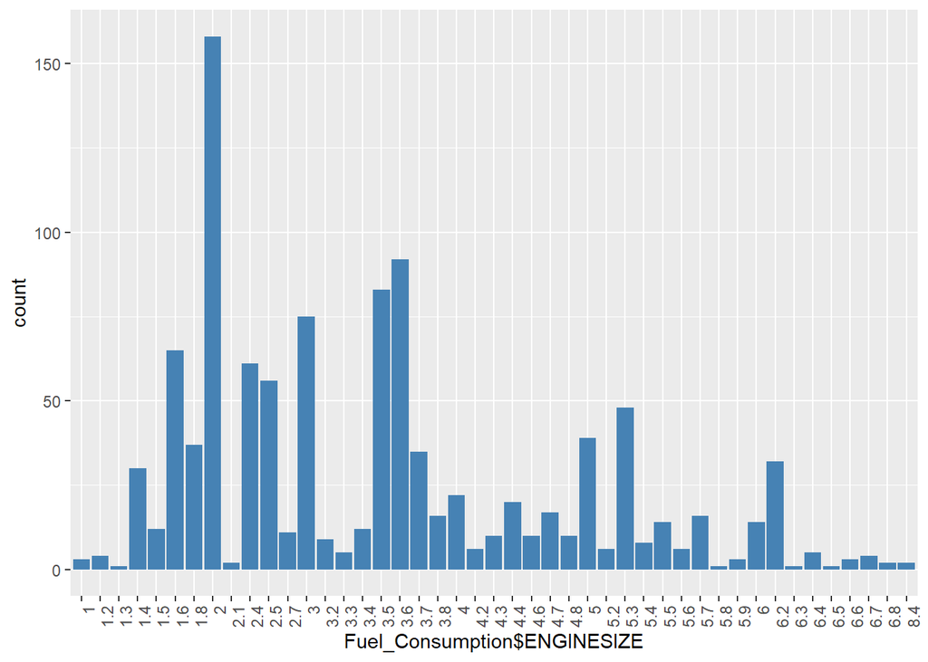

```r
par(mfrow=c(1,1),bg="lightyellow")
library(ggplot2)
ggplot(Fuel_Consumption,aes(Fuel_Consumption$ENGINESIZE))+geom_bar(fill="steelblue")+ theme(axis.text.x = element_text(angle = 90, hjust = 1))
```

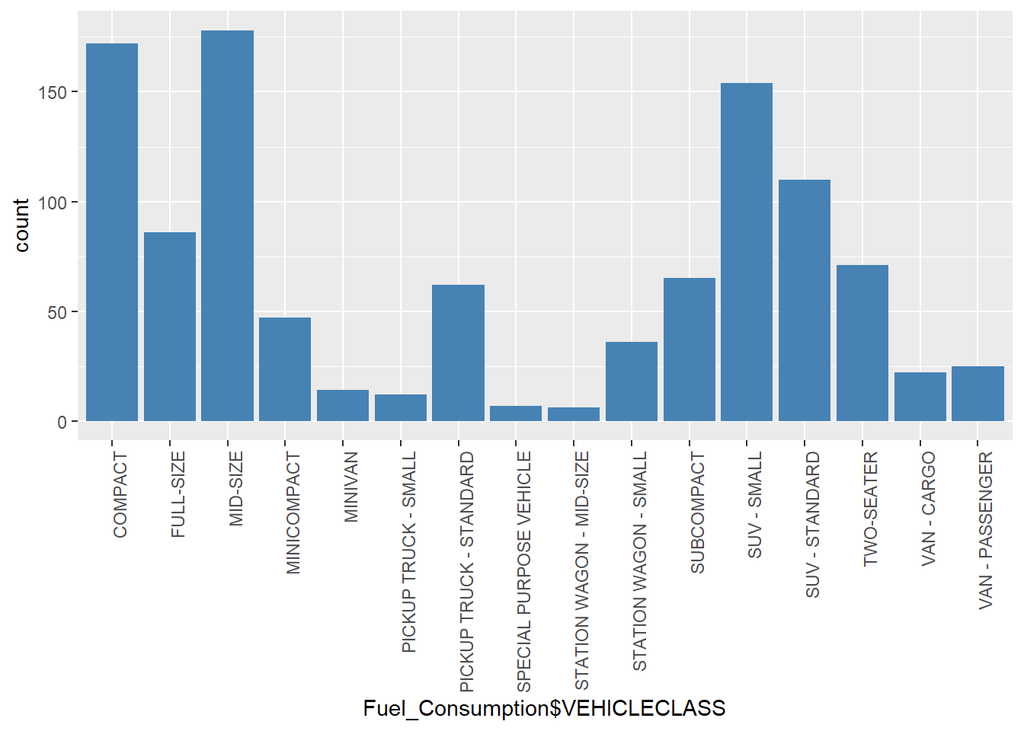

```r
ggplot(Fuel_Consumption,aes(Fuel_Consumption$VEHICLECLASS))+geom_bar(fill="steelblue")+ theme(axis.text.x = element_text(angle = 90, hjust = 1))
```

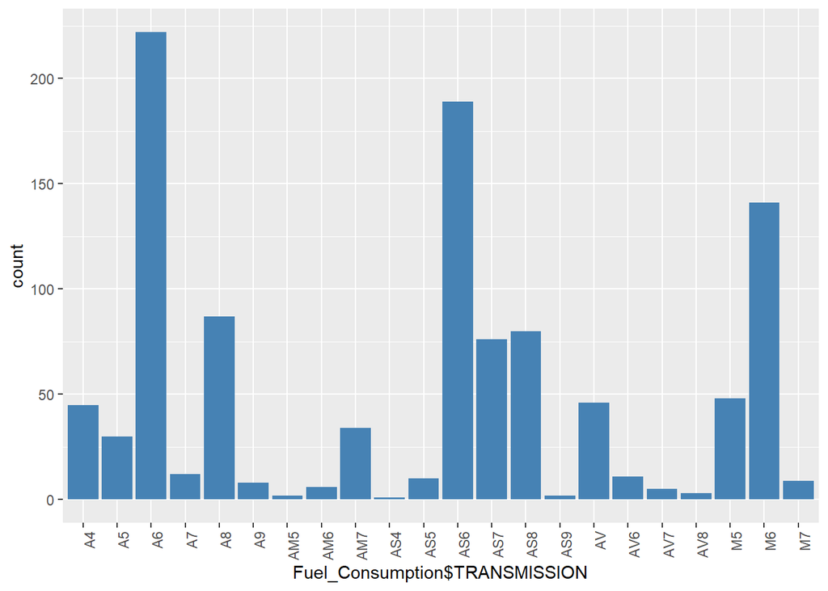

```r
ggplot(Fuel_Consumption,aes(Fuel_Consumption$TRANSMISSION))+geom_bar(fill="steelblue")+ theme(axis.text.x = element_text(angle = 90, hjust = 1))
```

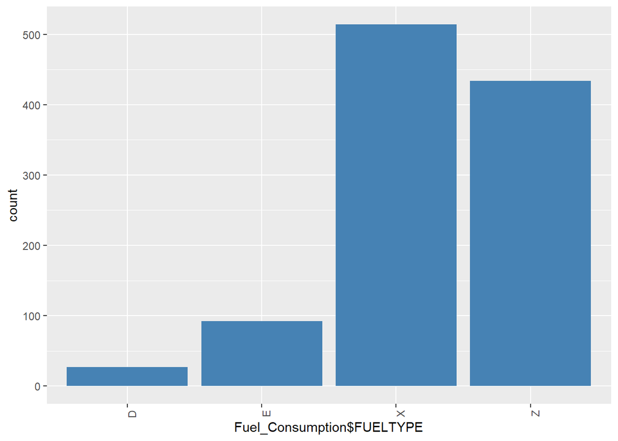

```r
ggplot(Fuel_Consumption,aes(Fuel_Consumption$FUELTYPE))+geom_bar(fill="steelblue")+ theme(axis.text.x = element_text(angle = 90, hjust = 1))
```

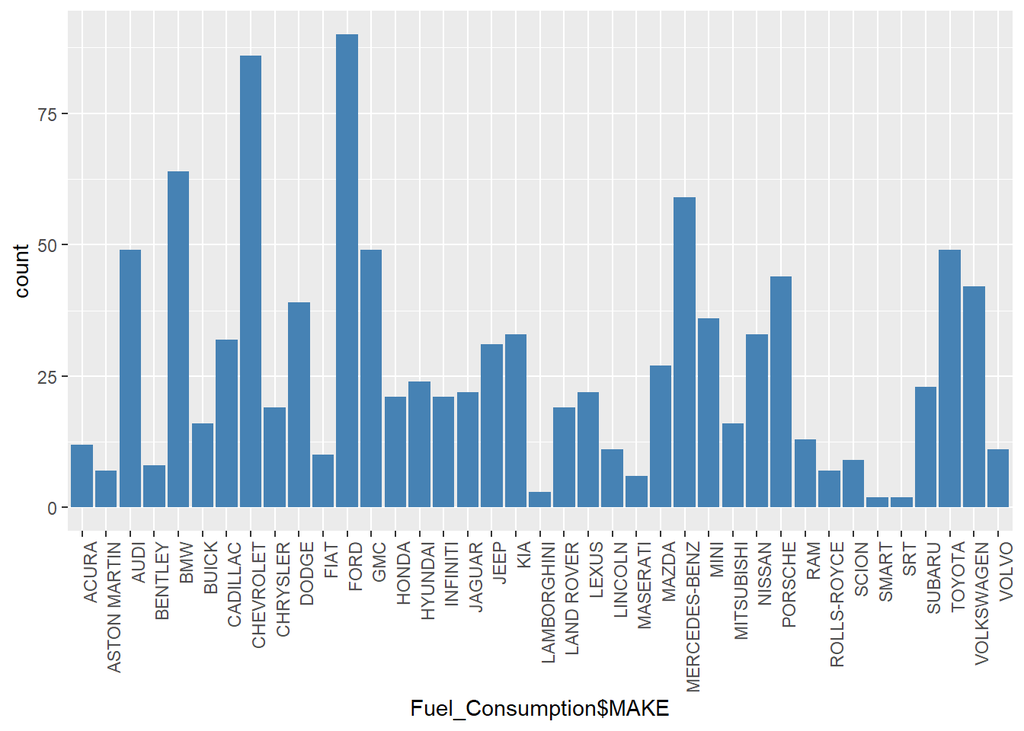

```r
ggplot(Fuel_Consumption,aes(Fuel_Consumption$MAKE))+geom_bar(fill="steelblue")+ theme(axis.text.x = element_text(angle = 90, hjust = 1))
```

## Data slicing

Data slicing is a method to filter and extract exact observations from the large data set according to the requirement. SUV Vehicles class is our requirement (Phillips, 2020).

**We are slicing the data from fuel consumption data to generate only SUV segment data. After implementing EDA, we found that maker JEEP produced more SUVs than any other and Popular engine size in this vehicle class 2.4liter and followed by 2liter.**

```r
library(ggplot2)

suv<-Fuel_Consumption[Fuel_Consumption$VEHICLECLASS=="SUV - SMALL"|Fuel_Consumption$VEHICLECLASS=="SUV - STANDARD",]
head(suv)
```

|  | MODELYEAR | MAKE | MODEL | VEHICLECLASS | ENGINESIZE | CYLINDERS | TRANSMISSION | FUELTYPE | FUELCONSUMPTION_CITY | FUELCONSUMPTION_HWY | FUELCONSUMPTION_COMB | FUELCONSUMPTION_COMB_MPG | CO2EMISSIONS |
| --- | --- | --- | --- | --- | --- | --- | --- | --- | --- | --- | --- | --- | --- |
| 4 | 2014 | ACURA | MDX 4WD | SUV - SMALL | 3.5 | 6 | AS6 | Z | 12.7 | 9.1 | 11.1 | 25 | 255 |
| 5 | 2014 | ACURA | RDX AWD | SUV - SMALL | 3.5 | 6 | AS6 | Z | 12.1 | 8.7 | 10.6 | 27 | 244 |
| 39 | 2014 | AUDI | Q5 | SUV - SMALL | 2 | 4 | AS8 | Z | 12.0 | 8.5 | 10.4 | 27 | 239 |
| 40 | 2014 | AUDI | Q5 | SUV - SMALL | 3 | 6 | AS8 | Z | 12.9 | 9.2 | 11.2 | 25 | 258 |
| 41 | 2014 | AUDI | Q5 HYBRID | SUV - SMALL | 2 | 4 | AS8 | Z | 9.9 | 8.3 | 9.2 | 31 | 212 |
| 42 | 2014 | AUDI | Q5 TDI CLEAN DIESEL | SUV - SMALL | 3 | 6 | AS8 | D | 10.3 | 7.6 | 9.1 | 31 | 246 |

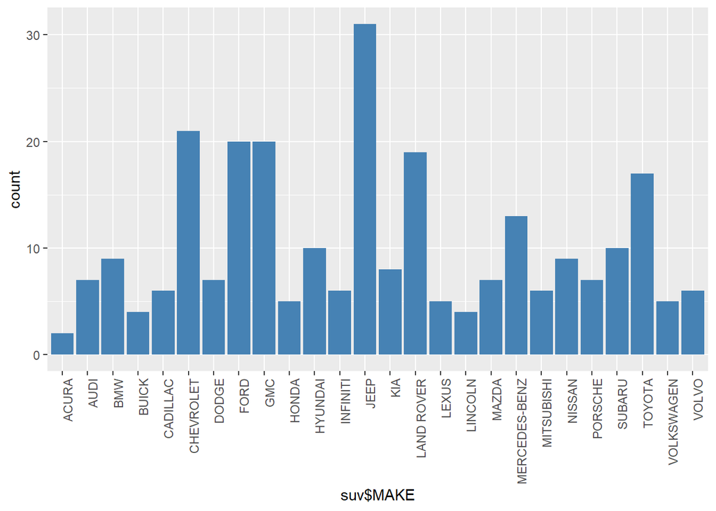

```r
ggplot(suv,aes(x=suv$MAKE))+geom_bar(fill="steelblue")+ theme(axis.text.x = element_text(angle = 90, hjust = 1))
```

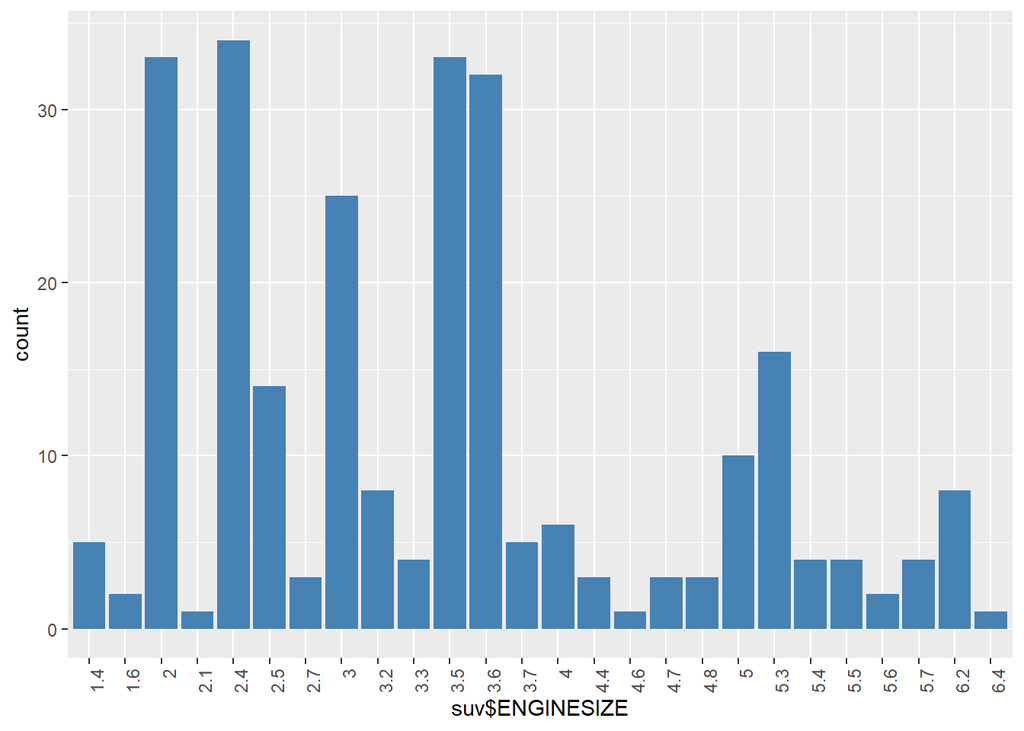

```r
ggplot(suv,aes(x=suv$ENGINESIZE))+geom_bar(fill="steelblue")+ theme(axis.text.x = element_text(angle = 90, hjust = 1))
```

## ANOVA

t-test is widely used to compare two individual samples. It cannot handle more than two samples. So, in order to handle more than 2 samples we use ANOVA which assumes that samples are taken from populations with the same variance, and variables should be independent and normally distributed. The NULL hypothesis here is the fuel consumption combined of all SUV makers are having the same mean while the ALTERNATIVE hypothesis is means are not same (Statisticallysignificantconsulting.com, 2020).

**Applying anova on combined mileage against different SUV Makers and found that to reject null hypothesis citing the p-value.**

```r
suv.aov<-aov(FUELCONSUMPTION_COMB~MAKE,data=suv)
summary(suv.aov)
```

```
##              Df Sum Sq Mean Sq F value   Pr(>F)
## MAKE         25  869.5   34.78   5.171 2.72e-12 ***
## Residuals   238 1601.0    6.73
## ---
## Signif. codes:  0 '***' 0.001 '**' 0.01 '*' 0.05 '.' 0.1 ' ' 1
```

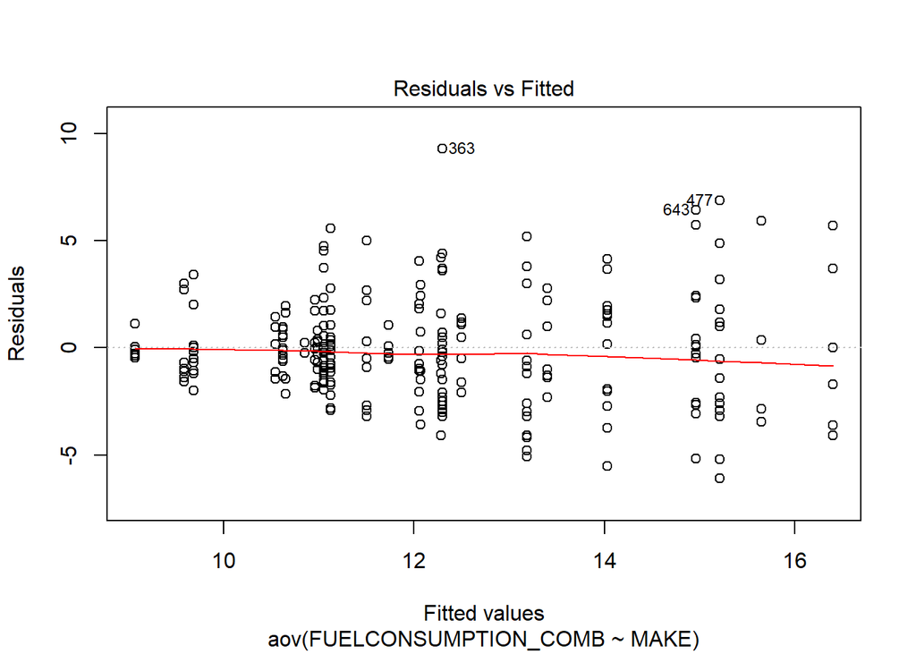

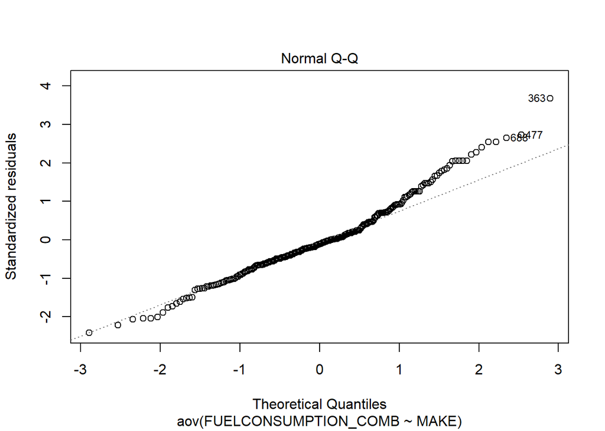

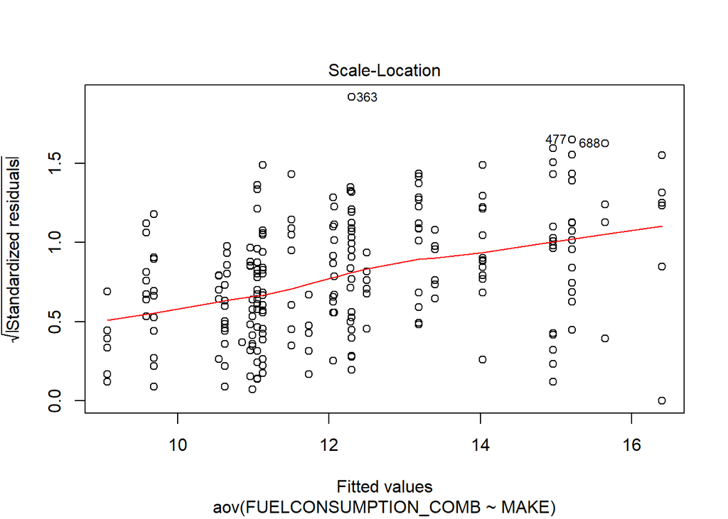

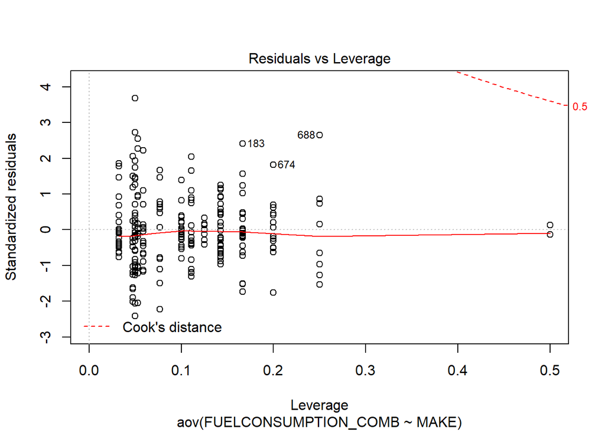

```r
plot(suv.aov,cex=1)
```

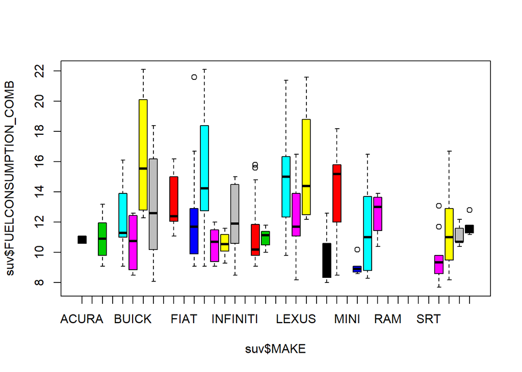

```r
plot(suv$FUELCONSUMPTION_COMB~suv$MAKE,data=suv,col=1:30)
```

```r
suv.aov_highway<-aov(FUELCONSUMPTION_HWY~MAKE,data=suv)
summary(suv.aov_highway)
```

```
##              Df Sum Sq Mean Sq F value   Pr(>F)
## MAKE         25    479  19.160   4.496 2.59e-10 ***
## Residuals   238   1014   4.262
## ---
## Signif. codes:  0 '***' 0.001 '**' 0.01 '*' 0.05 '.' 0.1 ' ' 1
```

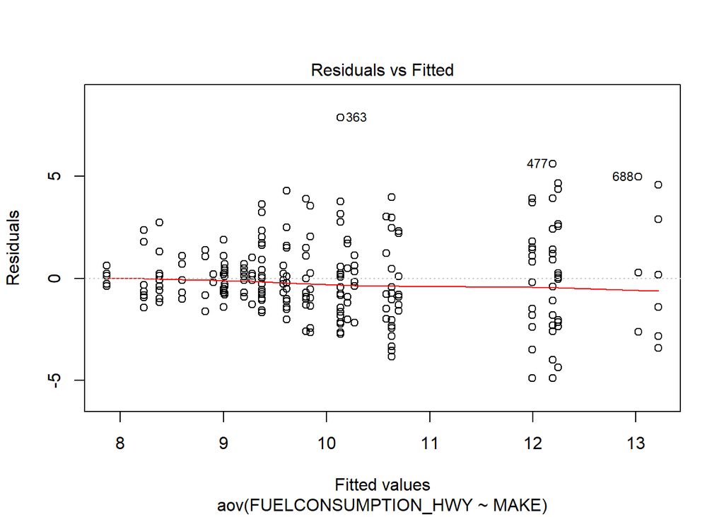

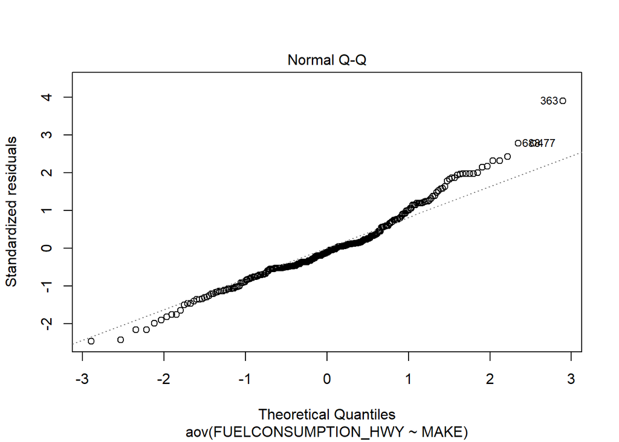

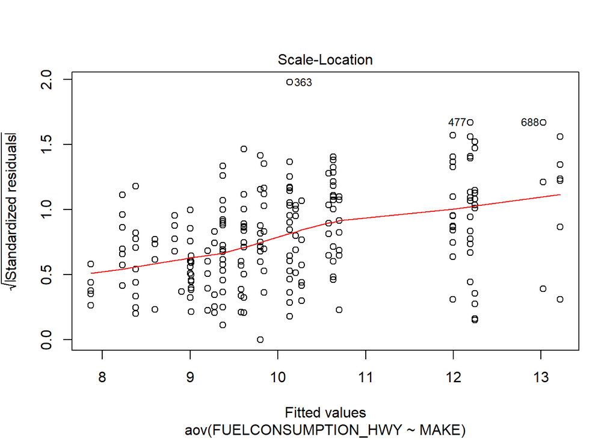

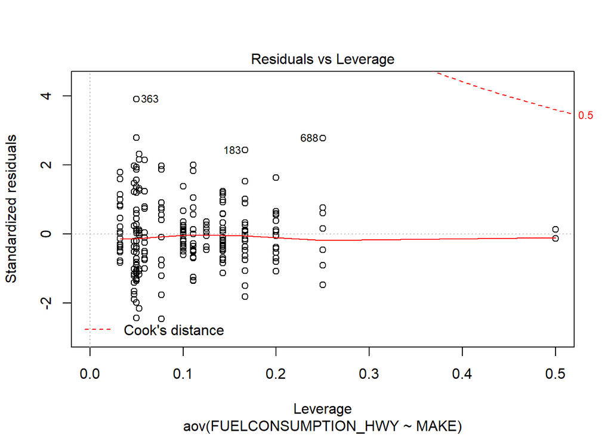

```r
plot(suv.aov_highway,cex=1)
```

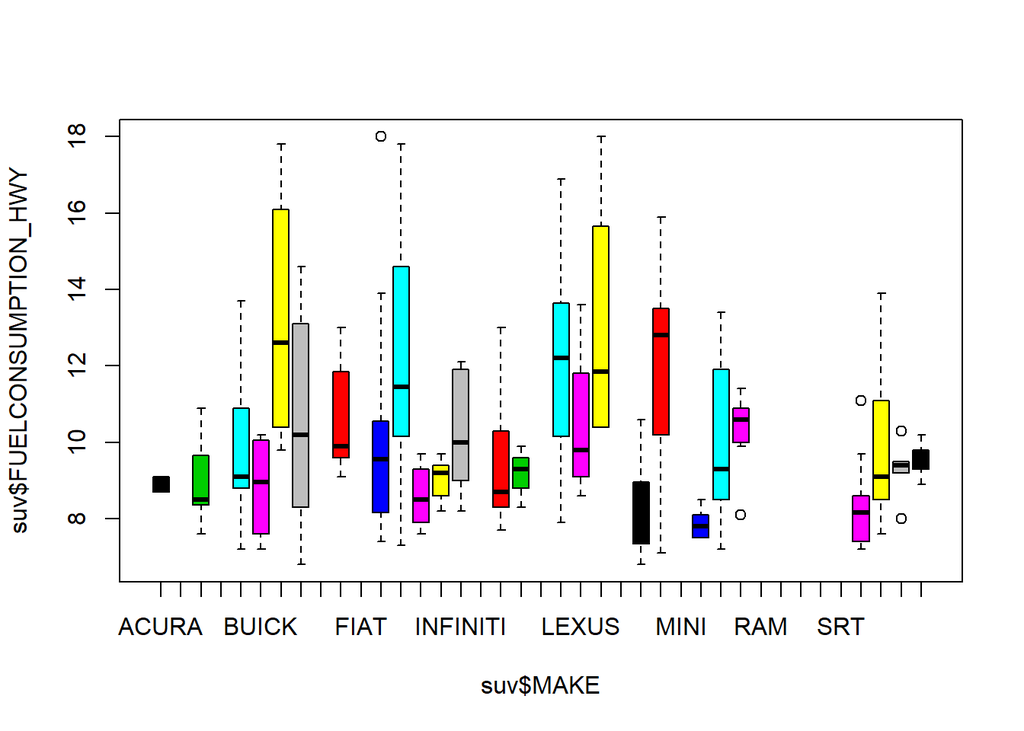

```r
plot(suv$FUELCONSUMPTION_HWY~suv$MAKE,data=suv,col=1:30)
```

```r
suv.aov_city<-aov(FUELCONSUMPTION_CITY~MAKE,data=suv)
summary(suv.aov_city)
```

```
##              Df Sum Sq Mean Sq F value   Pr(>F)
## MAKE         25   1292   51.68   5.514 2.75e-13 ***
## Residuals   238   2231    9.37
## ---
## Signif. codes:  0 '***' 0.001 '**' 0.01 '*' 0.05 '.' 0.1 ' ' 1
```

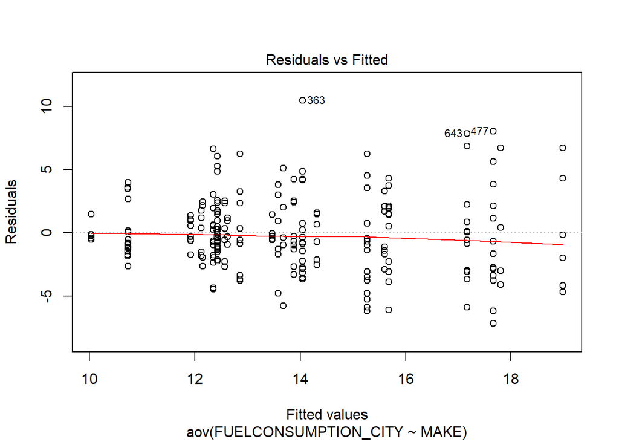

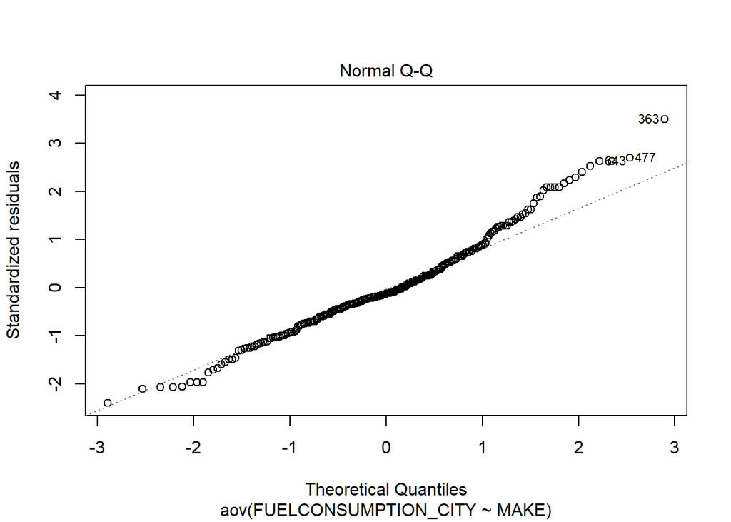

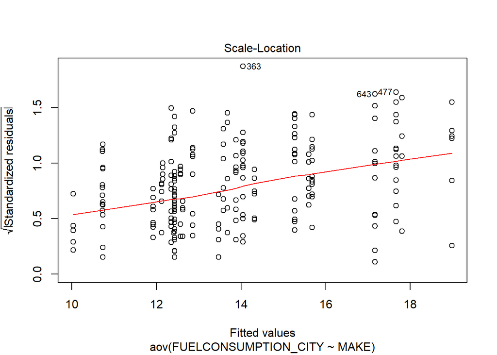

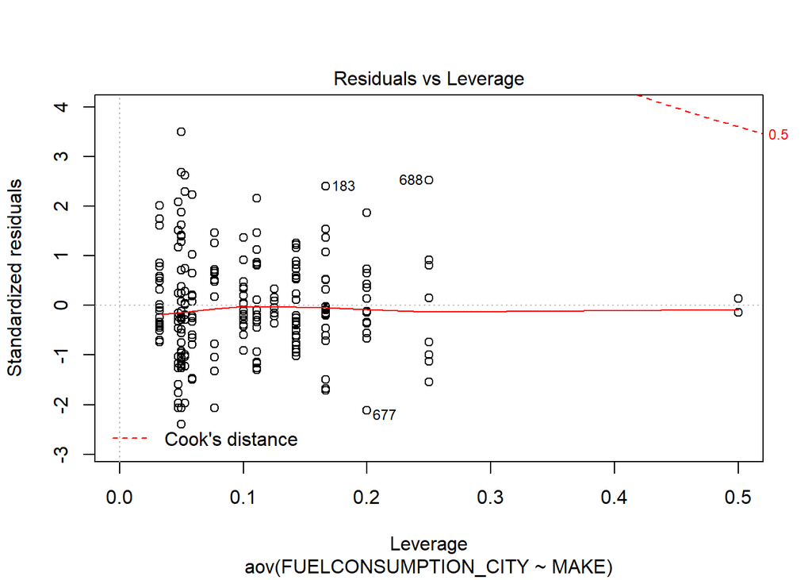

```r
plot(suv.aov_city,cex=1)
```

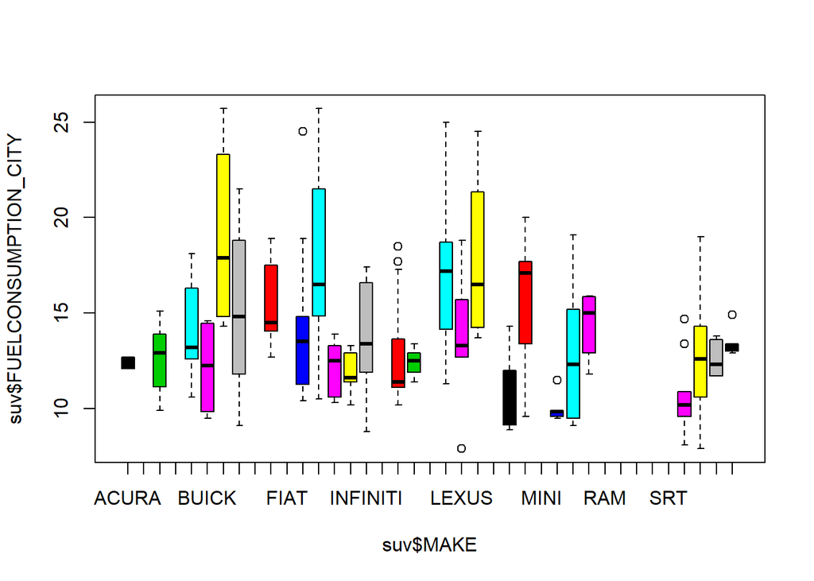

```r
plot(suv$FUELCONSUMPTION_CITY~suv$MAKE,data=suv,col=1:30)
```

```r
suv.aov_model<-aov(FUELCONSUMPTION_COMB~MODEL,data=suv)
summary(suv.aov_model)
```

```
##              Df Sum Sq Mean Sq F value   Pr(>F)
## MODEL       179   2046   11.43   2.259 2.26e-05 ***
## Residuals    84    425    5.06
## ---
## Signif. codes:  0 '***' 0.001 '**' 0.01 '*' 0.05 '.' 0.1 ' ' 1
```

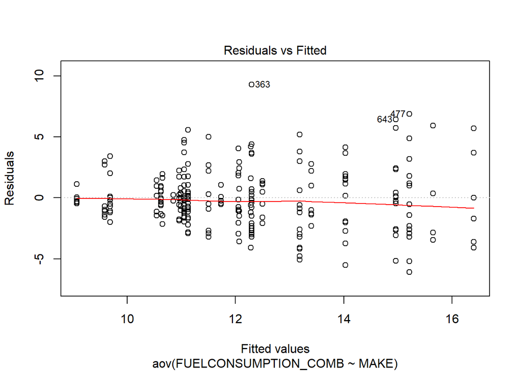

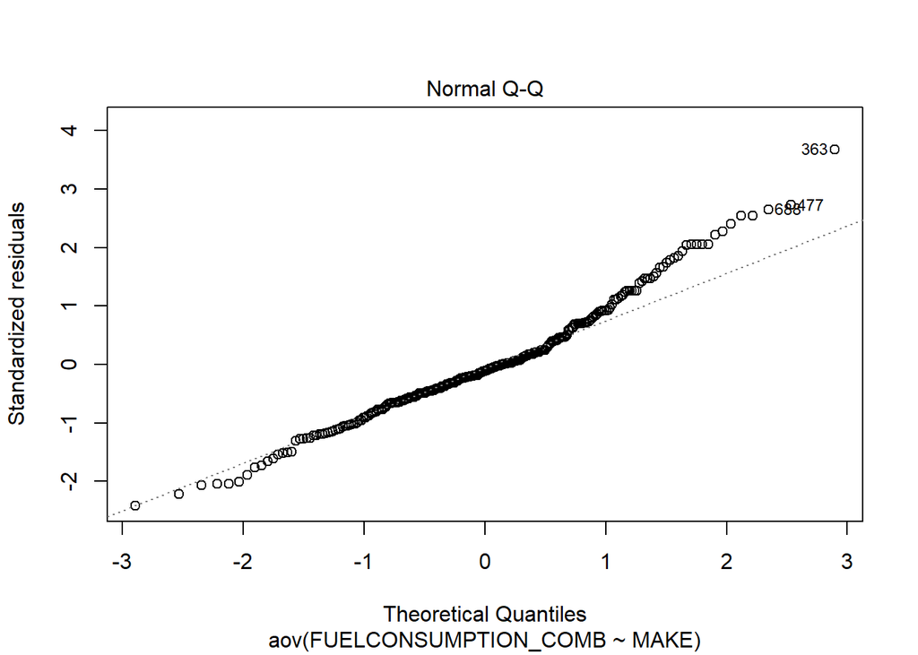

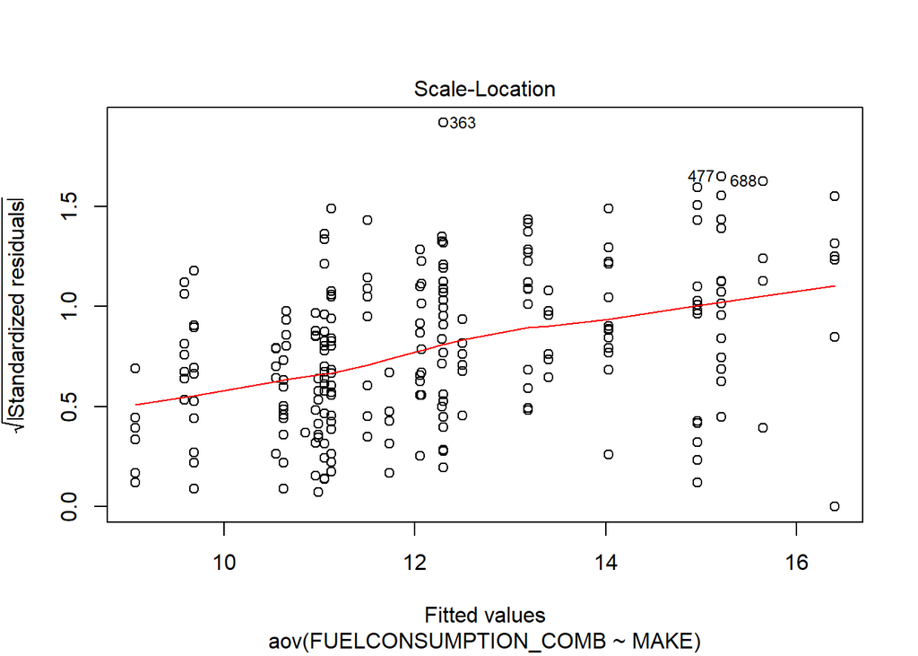

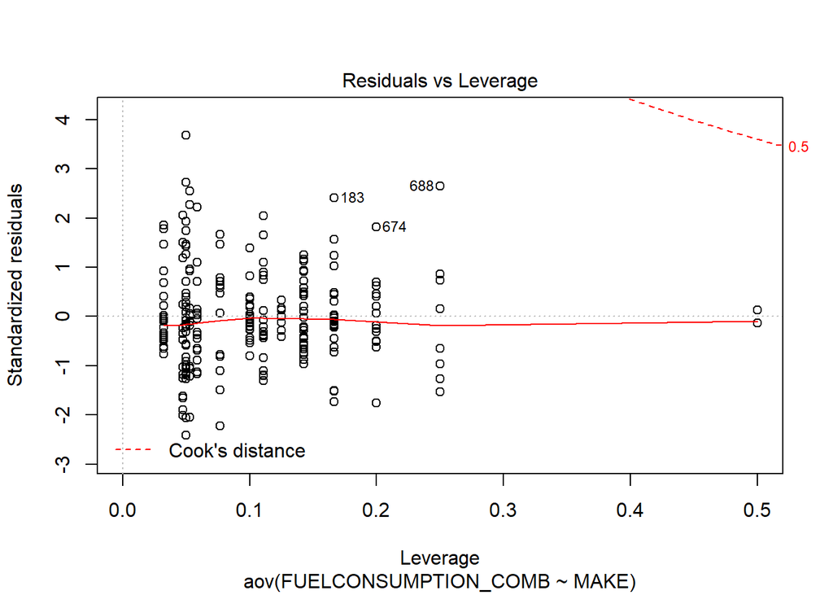

```r
plot(suv.aov,cex=1)
```

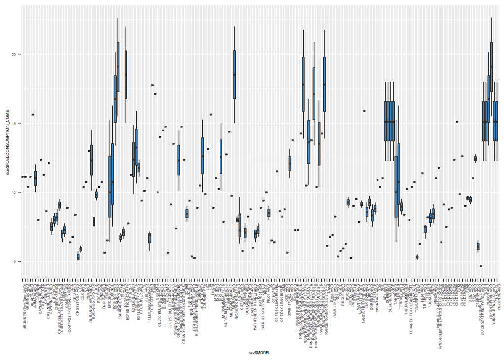

```r
ggplot(suv,aes(x=suv$MODEL,y=suv$FUELCONSUMPTION_COMB))+geom_boxplot(fill="steelblue")+ theme(text = element_text(size=4) ,axis.text.x = element_text(angle = 90, hjust = 1))
```

**Applying anova on combined mileage against different SUV Makers and found that to reject null hypothesis citing the p-value.**

```r
suv.aov_mpg<-aov(FUELCONSUMPTION_COMB_MPG~MAKE,data=suv)
summary(suv.aov_mpg)
```

```
##              Df Sum Sq Mean Sq F value   Pr(>F)
## MAKE         25   2695  107.79   5.256 1.53e-12 ***
## Residuals   238   4881   20.51
## ---
## Signif. codes:  0 '***' 0.001 '**' 0.01 '*' 0.05 '.' 0.1 ' ' 1
```

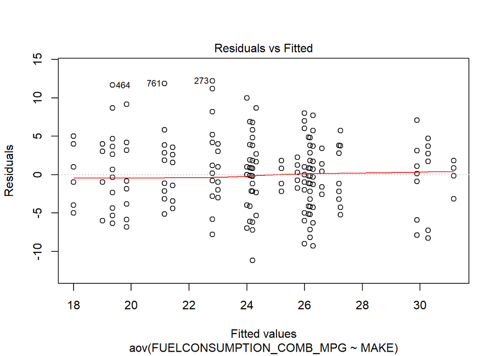

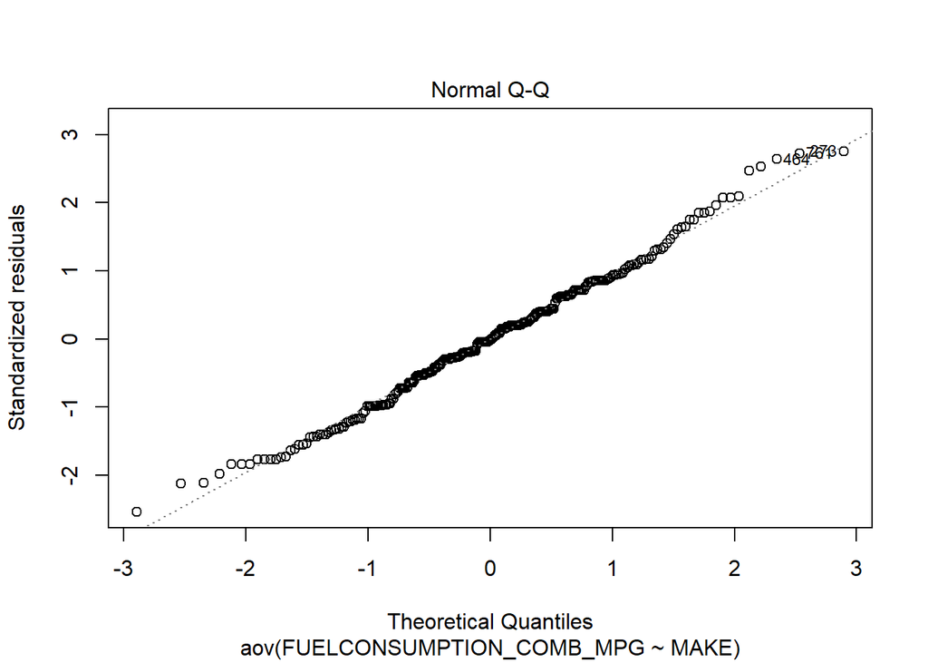

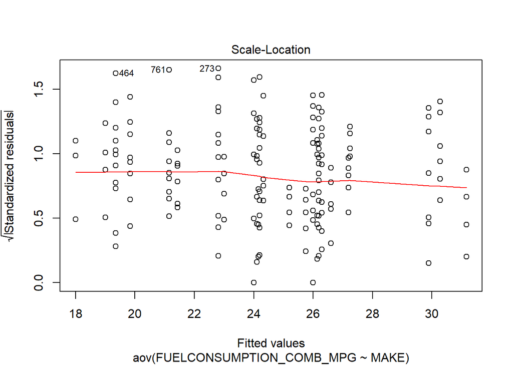

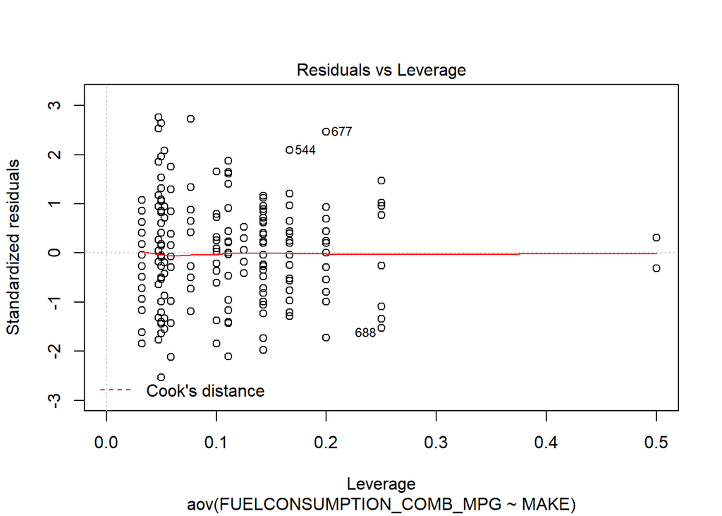

```r
plot(suv.aov_mpg,cex=1)
```

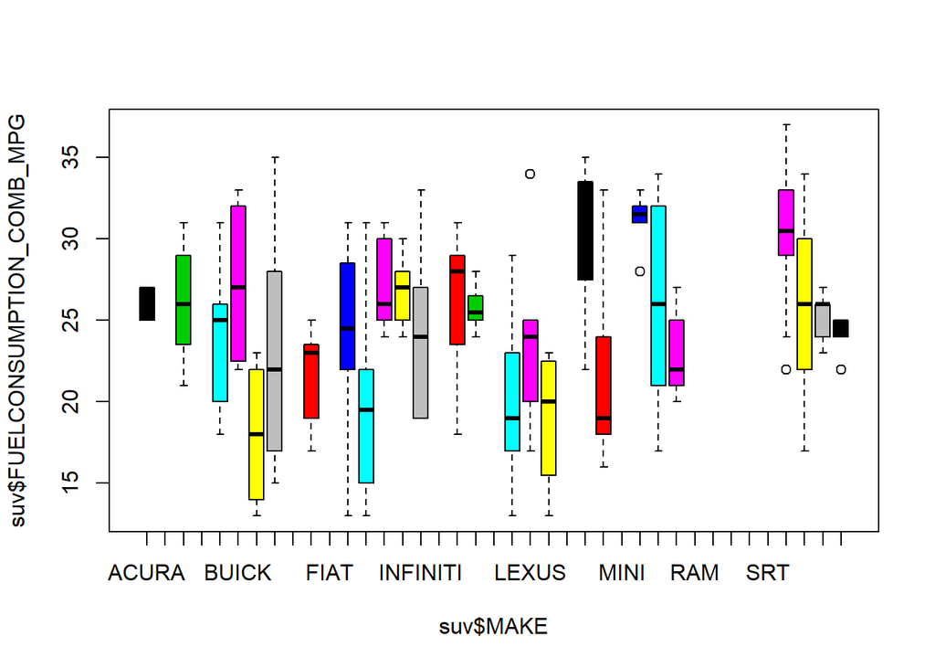

```r
plot(suv$FUELCONSUMPTION_COMB_MPG~suv$MAKE,data=suv,col=1:30)
```

## Bartlett Test

Unlike ANOVA test where it assumes that variances are equal across groups or samples. Bartlett test can be used for k samples and for all. Below equations, si2 is the variance of the ith group, N is the total sample size, Ni is the sample size of the ith group, k is the number of groups, and sp2 is the pooled variance. The pooled variance is a weighted average of the group variances (Itl.nist.gov, 2020). NULL hypothesis that different fuel consumption vs different car makes variances are equal, ALTERNATIVE is at least two car makes unequal.

$$s^{2}_{p} = \sum_{i=1}^{k}(N_{i} - 1)s^{2}_{i}/(N-k)$$

$$T = \frac{(N-k) \ln{s^{2}_{p}} - \sum_{i=1}^{k}(N_{i} - 1)\ln{s^{2}_{i}}}{1 + (1/(3(k-1)))((\sum_{i=1}^{k}{1/(N_{i} - 1))} - 1/(N-k))}$$

**Bartlett Test for equal variances different mileage setups against different SUV Makers and found that to reject null hypothesis citing the p-values.**

```r
bartlett.test(suv$FUELCONSUMPTION_COMB_MPG~suv$MAKE)
```

```
##
##  Bartlett test of homogeneity of variances
##
## data:  suv$FUELCONSUMPTION_COMB_MPG by suv$MAKE
## Bartlett's K-squared = 53.934, df = 25, p-value = 0.0006777
```

```r
bartlett.test(suv$FUELCONSUMPTION_CITY~suv$MAKE)
```

```
##
##  Bartlett test of homogeneity of variances
##
## data:  suv$FUELCONSUMPTION_CITY by suv$MAKE
## Bartlett's K-squared = 83.191, df = 25, p-value = 3.578e-08
```

```r
bartlett.test(suv$FUELCONSUMPTION_HWY~suv$MAKE)
```

```
##
##  Bartlett test of homogeneity of variances
##
## data:  suv$FUELCONSUMPTION_HWY by suv$MAKE
## Bartlett's K-squared = 93.451, df = 25, p-value = 7.763e-10
```

```r
bartlett.test(suv$FUELCONSUMPTION_COMB~suv$MAKE)
```

```
##
##  Bartlett test of homogeneity of variances
##
## data:  suv$FUELCONSUMPTION_COMB by suv$MAKE
## Bartlett's K-squared = 89.363, df = 25, p-value = 3.634e-09
```

**Citing the P values we reject the null hypothesis.**

```r
wilcox.test(suv$FUELCONSUMPTION_CITY,suv$FUELCONSUMPTION_HWY,conf.int=0.99,mu=0)
```

```
##
##  Wilcoxon rank sum test with continuity correction
##
## data:  suv$FUELCONSUMPTION_CITY and suv$FUELCONSUMPTION_HWY
## W = 57572, p-value < 2.2e-16
## alternative hypothesis: true location shift is not equal to 0
## 95 percent confidence interval:
##  2.999954 3.900035
## sample estimates:
## difference in location
##               3.400048
```

```r
wilcox.test(suv$FUELCONSUMPTION_CITY,suv$FUELCONSUMPTION_COMB,conf.int=0.99,mu=0)
```

```
##
##  Wilcoxon rank sum test with continuity correction
##
## data:  suv$FUELCONSUMPTION_CITY and suv$FUELCONSUMPTION_COMB
## W = 45143, p-value = 4.271e-09
## alternative hypothesis: true location shift is not equal to 0
## 95 percent confidence interval:
##  1.000024 2.099959
## sample estimates:
## difference in location
##               1.500017
```

```r
wilcox.test(suv$FUELCONSUMPTION_HWY,suv$FUELCONSUMPTION_COMB,conf.int=0.99,mu=0)
```

```
##
##  Wilcoxon rank sum test with continuity correction
##
## data:  suv$FUELCONSUMPTION_HWY and suv$FUELCONSUMPTION_COMB
## W = 19526, p-value < 2.2e-16
## alternative hypothesis: true location shift is not equal to 0
## 95 percent confidence interval:
##  -2.299987 -1.499927
## sample estimates:
## difference in location
##              -1.899991
```